# Part I - (Pokemon: Got to run them all!)

## BY (Tinika Darden)

### DATE October 27th 2022

# Table of Contents:

1.Introduction

2.Data Cleaning

3.Dataset function

4.Univariate Exploration

> 4.1PokeType Exploration

> 4.2PokeStats

> 4.3Univariate Recap

5.Bivariate Exploration

> 5.1Bivariate Recap

6.Multivariate Exploration

> 6.1Multivariate Recap

7.Conclusion

## Introduction

> For my final project for the Data Analyst nanodegree program, I have chosen to use a dataset provided by Udacity during my course work, "pokemon.csv". I chose the subject mostly because of nostalgia, and loving video games. I was hoping that it would also help me stay engaged as well as my readers.

> During this project I will load my chosen dataset, gather all the information needed to run various cells answering any questions that will arise.

> Thereafter I will be assesing the data and taking note of any information that needs to be cleaned or organized for maximum readability. I will be scrutinizing the given information and gathering any insights I plan on highlighting with my final clean table.

> Speaking of clean table, I will go over any noticeable changes that need to be made. Removing any duplicate rows, making the rows and columns uniform and organized. Moving any information to the appropriate column so that data is properly portrayed.

## Preliminary Wrangling

```python
# import all packages and set plots to be embedded inline
import numpy as np
import pandas as pd
import matplotlib.pyplot as plt
import seaborn as sb

%matplotlib inline
```

```python
# increasing the max rows that can be viewed.
pd.options.display.max_rows = 600
```

```python
#load the dataset that I will be working with
#call head to see a preview.
pokemon = pd.read_csv('pokemon.csv')
pokemon.head(10)
```

|  | id | species | generation_id | height | weight | base_experience | type_1 | type_2 | hp | attack | defense | speed | special-attack | special-defense |
| --- | --- | --- | --- | --- | --- | --- | --- | --- | --- | --- | --- | --- | --- | --- |
| 0 | 1 | bulbasaur | 1 | 0.7 | 6.9 | 64 | grass | poison | 45 | 49 | 49 | 45 | 65 | 65 |
| 1 | 2 | ivysaur | 1 | 1.0 | 13.0 | 142 | grass | poison | 60 | 62 | 63 | 60 | 80 | 80 |
| 2 | 3 | venusaur | 1 | 2.0 | 100.0 | 236 | grass | poison | 80 | 82 | 83 | 80 | 100 | 100 |
| 3 | 4 | charmander | 1 | 0.6 | 8.5 | 62 | fire | NaN | 39 | 52 | 43 | 65 | 60 | 50 |
| 4 | 5 | charmeleon | 1 | 1.1 | 19.0 | 142 | fire | NaN | 58 | 64 | 58 | 80 | 80 | 65 |
| 5 | 6 | charizard | 1 | 1.7 | 90.5 | 240 | fire | flying | 78 | 84 | 78 | 100 | 109 | 85 |
| 6 | 7 | squirtle | 1 | 0.5 | 9.0 | 63 | water | NaN | 44 | 48 | 65 | 43 | 50 | 64 |
| 7 | 8 | wartortle | 1 | 1.0 | 22.5 | 142 | water | NaN | 59 | 63 | 80 | 58 | 65 | 80 |
| 8 | 9 | blastoise | 1 | 1.6 | 85.5 | 239 | water | NaN | 79 | 83 | 100 | 78 | 85 | 105 |
| 9 | 10 | caterpie | 1 | 0.3 | 2.9 | 39 | bug | NaN | 45 | 30 | 35 | 45 | 20 | 20 |

```python
pokemon.sample(7)
```

|  | id | species | generation_id | height | weight | base_experience | type_1 | type_2 | hp | attack | defense | speed | special-attack | special-defense |
| --- | --- | --- | --- | --- | --- | --- | --- | --- | --- | --- | --- | --- | --- | --- |
| 285 | 286 | breloom | 3 | 1.2 | 39.2 | 161 | grass | fighting | 60 | 130 | 80 | 70 | 60 | 60 |
| 160 | 161 | sentret | 2 | 0.8 | 6.0 | 43 | normal | NaN | 35 | 46 | 34 | 20 | 35 | 45 |
| 688 | 689 | barbaracle | 6 | 1.3 | 96.0 | 175 | rock | water | 72 | 105 | 115 | 68 | 54 | 86 |
| 294 | 295 | exploud | 3 | 1.5 | 84.0 | 221 | normal | NaN | 104 | 91 | 63 | 68 | 91 | 73 |
| 785 | 786 | tapu-lele | 7 | 1.2 | 18.6 | 257 | psychic | fairy | 70 | 85 | 75 | 95 | 130 | 115 |
| 788 | 789 | cosmog | 7 | 0.2 | 0.1 | 40 | psychic | NaN | 43 | 29 | 31 | 37 | 29 | 31 |
| 775 | 776 | turtonator | 7 | 2.0 | 212.0 | 170 | fire | dragon | 60 | 78 | 135 | 36 | 91 | 85 |

> Load in your dataset and describe its properties through the questions below. Try and motivate your exploration goals through this section.

```python
pokemon.describe()
```

|  | id | generation_id | height | weight | base_experience | hp | attack | defense | speed | special-attack | special-defense |
| --- | --- | --- | --- | --- | --- | --- | --- | --- | --- | --- | --- |
| count | 807.000000 | 807.000000 | 807.000000 | 807.000000 | 807.000000 | 807.000000 | 807.000000 | 807.000000 | 807.000000 | 807.000000 | 807.000000 |
| mean | 404.000000 | 3.714994 | 1.162454 | 61.771128 | 144.848823 | 68.748451 | 76.086741 | 71.726146 | 65.830235 | 69.486989 | 70.013631 |
| std | 233.105126 | 1.944148 | 1.081030 | 111.519355 | 74.953116 | 26.032808 | 29.544598 | 29.730228 | 27.736838 | 29.439715 | 27.292344 |
| min | 1.000000 | 1.000000 | 0.100000 | 0.100000 | 36.000000 | 1.000000 | 5.000000 | 5.000000 | 5.000000 | 10.000000 | 20.000000 |
| 25% | 202.500000 | 2.000000 | 0.600000 | 9.000000 | 66.000000 | 50.000000 | 55.000000 | 50.000000 | 45.000000 | 45.000000 | 50.000000 |
| 50% | 404.000000 | 4.000000 | 1.000000 | 27.000000 | 151.000000 | 65.000000 | 75.000000 | 67.000000 | 65.000000 | 65.000000 | 65.000000 |
| 75% | 605.500000 | 5.000000 | 1.500000 | 63.000000 | 179.500000 | 80.000000 | 95.000000 | 89.000000 | 85.000000 | 90.000000 | 85.000000 |
| max | 807.000000 | 7.000000 | 14.500000 | 999.900000 | 608.000000 | 255.000000 | 181.000000 | 230.000000 | 160.000000 | 173.000000 | 230.000000 |

```python
#View the whole column list to see dtypes and non-null count
pokemon.info()
```

```
<class 'pandas.core.frame.DataFrame'>
RangeIndex: 807 entries, 0 to 806
Data columns (total 14 columns):
 #   Column           Non-Null Count  Dtype
---  ------           --------------  -----
 0   id               807 non-null    int64
 1   species          807 non-null    object
 2   generation_id    807 non-null    int64
 3   height           807 non-null    float64
 4   weight           807 non-null    float64
 5   base_experience  807 non-null    int64
 6   type_1           807 non-null    object
 7   type_2           405 non-null    object
 8   hp               807 non-null    int64
 9   attack           807 non-null    int64
 10  defense          807 non-null    int64
 11  speed            807 non-null    int64
 12  special-attack   807 non-null    int64
 13  special-defense  807 non-null    int64
dtypes: float64(2), int64(9), object(3)
memory usage: 88.4+ KB
```

```python
#View the rows and columns to see the structure of your dataset
pokemon.shape
```

```
(807, 14)
```

```python
pokemon_na = pokemon['species'].isnull().values.any()
print(pokemon_na)
```

```
False
```

```python
#Check to see if there are any duplicates in the dataset.
pokemon.duplicated()
```

```
0      False
1      False
2      False
3      False
4      False
       ...
802    False
803    False
804    False
805    False
806    False
Length: 807, dtype: bool
```

```python
#What does the value_count look like for the pokemon hp
pokemons_hp = pokemon.hp.value_counts()
```

```python
#condensed summary of the statistical information
pokemon.hp.describe()
```

```
count    807.000000
mean      68.748451
std       26.032808
min        1.000000
25%       50.000000
50%       65.000000
75%       80.000000
max      255.000000
Name: hp, dtype: float64
```

```python
pokemon.type_1.value_counts()
```

```
water       114
normal      105
grass        78
bug          72
fire         53
psychic      53
rock         46
electric     40
poison       34
ground       32
dark         29
fighting     29
ghost        27
dragon       27
steel        24
ice          23
fairy        18
flying        3
Name: type_1, dtype: int64
```

```python
pokemon.generation_id.value_counts()
```

```
5    156
1    151
3    135
4    107
2    100
7     86
6     72
Name: generation_id, dtype: int64
```

```python
# Make copies of original pieces of data
pk = pokemon.copy()
```

### Define:Data Cleaning

```python
#Change the dtype for id
pk.id = pk.id.astype(str)
```

```python
pk
```

|  | id | species | generation_id | height | weight | base_experience | type_1 | type_2 | hp | attack | defense | speed | special-attack | special-defense |
| --- | --- | --- | --- | --- | --- | --- | --- | --- | --- | --- | --- | --- | --- | --- |
| 0 | 1 | bulbasaur | 1 | 0.7 | 6.9 | 64 | grass | poison | 45 | 49 | 49 | 45 | 65 | 65 |
| 1 | 2 | ivysaur | 1 | 1.0 | 13.0 | 142 | grass | poison | 60 | 62 | 63 | 60 | 80 | 80 |
| 2 | 3 | venusaur | 1 | 2.0 | 100.0 | 236 | grass | poison | 80 | 82 | 83 | 80 | 100 | 100 |
| 3 | 4 | charmander | 1 | 0.6 | 8.5 | 62 | fire | NaN | 39 | 52 | 43 | 65 | 60 | 50 |
| 4 | 5 | charmeleon | 1 | 1.1 | 19.0 | 142 | fire | NaN | 58 | 64 | 58 | 80 | 80 | 65 |
| ... | ... | ... | ... | ... | ... | ... | ... | ... | ... | ... | ... | ... | ... | ... |
| 802 | 803 | poipole | 7 | 0.6 | 1.8 | 189 | poison | NaN | 67 | 73 | 67 | 73 | 73 | 67 |
| 803 | 804 | naganadel | 7 | 3.6 | 150.0 | 243 | poison | dragon | 73 | 73 | 73 | 121 | 127 | 73 |
| 804 | 805 | stakataka | 7 | 5.5 | 820.0 | 257 | rock | steel | 61 | 131 | 211 | 13 | 53 | 101 |
| 805 | 806 | blacephalon | 7 | 1.8 | 13.0 | 257 | fire | ghost | 53 | 127 | 53 | 107 | 151 | 79 |
| 806 | 807 | zeraora | 7 | 1.5 | 44.5 | 270 | electric | NaN | 88 | 112 | 75 | 143 | 102 | 80 |

807 rows × 14 columns

```python
#Lets rename the columns to give this table a more uniform look.
pk.rename(index = str, columns ={'id': 'ID', 'species': 'Species', 'generation_id': 'Generation_ID',
                                 'height': 'Height', 'weight': 'Weight', 'base_experience': 'Base_EXP',
                                 'type_1': 'Type_1', 'type_2': 'Type_2', 'hp': 'HP', 'attack': 'ATK',
                                 'defense': 'DEF', 'speed': 'Speed', 'special-attack': 'Special_ATK',
                                 'special-defense': 'Special_DEF'}, inplace=True)
pk.head()
```

|  | ID | Species | Generation_ID | Height | Weight | Base_EXP | Type_1 | Type_2 | HP | ATK | DEF | Speed | Special_ATK | Special_DEF |
| --- | --- | --- | --- | --- | --- | --- | --- | --- | --- | --- | --- | --- | --- | --- |
| 0 | 1 | bulbasaur | 1 | 0.7 | 6.9 | 64 | grass | poison | 45 | 49 | 49 | 45 | 65 | 65 |
| 1 | 2 | ivysaur | 1 | 1.0 | 13.0 | 142 | grass | poison | 60 | 62 | 63 | 60 | 80 | 80 |
| 2 | 3 | venusaur | 1 | 2.0 | 100.0 | 236 | grass | poison | 80 | 82 | 83 | 80 | 100 | 100 |
| 3 | 4 | charmander | 1 | 0.6 | 8.5 | 62 | fire | NaN | 39 | 52 | 43 | 65 | 60 | 50 |
| 4 | 5 | charmeleon | 1 | 1.1 | 19.0 | 142 | fire | NaN | 58 | 64 | 58 | 80 | 80 | 65 |

```python
#Capitolize the species.
pk.Species = pk.Species.str.title()
pk.sample(7)
```

|  | ID | Species | Generation_ID | Height | Weight | Base_EXP | Type_1 | Type_2 | HP | ATK | DEF | Speed | Special_ATK | Special_DEF |
| --- | --- | --- | --- | --- | --- | --- | --- | --- | --- | --- | --- | --- | --- | --- |
| 611 | 612 | Haxorus | 5 | 1.8 | 105.5 | 243 | dragon | NaN | 76 | 147 | 90 | 97 | 60 | 70 |
| 567 | 568 | Trubbish | 5 | 0.6 | 31.0 | 66 | poison | NaN | 50 | 50 | 62 | 65 | 40 | 62 |
| 467 | 468 | Togekiss | 4 | 1.5 | 38.0 | 245 | fairy | flying | 85 | 50 | 95 | 80 | 120 | 115 |
| 39 | 40 | Wigglytuff | 1 | 1.0 | 12.0 | 196 | normal | fairy | 140 | 70 | 45 | 45 | 85 | 50 |
| 479 | 480 | Uxie | 4 | 0.3 | 0.3 | 261 | psychic | NaN | 75 | 75 | 130 | 95 | 75 | 130 |
| 732 | 733 | Toucannon | 7 | 1.1 | 26.0 | 218 | normal | flying | 80 | 120 | 75 | 60 | 75 | 75 |
| 478 | 479 | Rotom | 4 | 0.3 | 0.3 | 154 | electric | ghost | 50 | 50 | 77 | 91 | 95 | 77 |

```python
#Capitolize the poketypes
pk.Type_1 = pk.Type_1.str.title()
pk.sample(11)
```

|  | ID | Species | Generation_ID | Height | Weight | Base_EXP | Type_1 | Type_2 | HP | ATK | DEF | Speed | Special_ATK | Special_DEF |
| --- | --- | --- | --- | --- | --- | --- | --- | --- | --- | --- | --- | --- | --- | --- |
| 746 | 747 | Mareanie | 7 | 0.4 | 8.0 | 61 | Poison | water | 50 | 53 | 62 | 45 | 43 | 52 |
| 332 | 333 | Swablu | 3 | 0.4 | 1.2 | 62 | Normal | flying | 45 | 40 | 60 | 50 | 40 | 75 |
| 787 | 788 | Tapu-Fini | 7 | 1.3 | 21.2 | 257 | Water | fairy | 70 | 75 | 115 | 85 | 95 | 130 |
| 401 | 402 | Kricketune | 4 | 1.0 | 25.5 | 134 | Bug | NaN | 77 | 85 | 51 | 65 | 55 | 51 |
| 751 | 752 | Araquanid | 7 | 1.8 | 82.0 | 159 | Water | bug | 68 | 70 | 92 | 42 | 50 | 132 |
| 702 | 703 | Carbink | 6 | 0.3 | 5.7 | 100 | Rock | fairy | 50 | 50 | 150 | 50 | 50 | 150 |
| 778 | 779 | Bruxish | 7 | 0.9 | 19.0 | 166 | Water | psychic | 68 | 105 | 70 | 92 | 70 | 70 |
| 158 | 159 | Croconaw | 2 | 1.1 | 25.0 | 142 | Water | NaN | 65 | 80 | 80 | 58 | 59 | 63 |
| 487 | 488 | Cresselia | 4 | 1.5 | 85.6 | 270 | Psychic | NaN | 120 | 70 | 120 | 85 | 75 | 130 |
| 604 | 605 | Elgyem | 5 | 0.5 | 9.0 | 67 | Psychic | NaN | 55 | 55 | 55 | 30 | 85 | 55 |
| 722 | 723 | Dartrix | 7 | 0.7 | 16.0 | 147 | Grass | flying | 78 | 75 | 75 | 52 | 70 | 70 |

```python
#Capitolizing the Type 2 poketypes.
pk.Type_2 = pk.Type_2.str.title()
pk.sample(7)
```

|  | ID | Species | Generation_ID | Height | Weight | Base_EXP | Type_1 | Type_2 | HP | ATK | DEF | Speed | Special_ATK | Special_DEF |
| --- | --- | --- | --- | --- | --- | --- | --- | --- | --- | --- | --- | --- | --- | --- |
| 629 | 630 | Mandibuzz | 5 | 1.2 | 39.5 | 179 | Dark | Flying | 110 | 65 | 105 | 80 | 55 | 95 |
| 740 | 741 | Oricorio | 7 | 0.6 | 3.4 | 167 | Fire | Flying | 75 | 70 | 70 | 93 | 98 | 70 |
| 25 | 26 | Raichu | 1 | 0.8 | 30.0 | 218 | Electric | NaN | 60 | 90 | 55 | 110 | 90 | 80 |
| 210 | 211 | Qwilfish | 2 | 0.5 | 3.9 | 88 | Water | Poison | 65 | 95 | 85 | 85 | 55 | 55 |
| 801 | 802 | Marshadow | 7 | 0.7 | 22.2 | 270 | Fighting | Ghost | 90 | 125 | 80 | 125 | 90 | 90 |
| 129 | 130 | Gyarados | 1 | 6.5 | 235.0 | 189 | Water | Flying | 95 | 125 | 79 | 81 | 60 | 100 |
| 618 | 619 | Mienfoo | 5 | 0.9 | 20.0 | 70 | Fighting | NaN | 45 | 85 | 50 | 65 | 55 | 50 |

```python
#Overview of the Pokemon Table
pk.info()
```

```
<class 'pandas.core.frame.DataFrame'>
Index: 807 entries, 0 to 806
Data columns (total 14 columns):
 #   Column         Non-Null Count  Dtype
---  ------         --------------  -----
 0   ID             807 non-null    object
 1   Species        807 non-null    object
 2   Generation_ID  807 non-null    int64
 3   Height         807 non-null    float64
 4   Weight         807 non-null    float64
 5   Base_EXP       807 non-null    int64
 6   Type_1         807 non-null    object
 7   Type_2         405 non-null    object
 8   HP             807 non-null    int64
 9   ATK            807 non-null    int64
 10  DEF            807 non-null    int64
 11  Speed          807 non-null    int64
 12  Special_ATK    807 non-null    int64
 13  Special_DEF    807 non-null    int64
dtypes: float64(2), int64(8), object(4)
memory usage: 94.6+ KB
```

```python
pk = pk.replace({np.nan: None})
```

```python
pk = pd.read_csv('Pokemon_master.csv')
pk.info()
```

```
<class 'pandas.core.frame.DataFrame'>
RangeIndex: 807 entries, 0 to 806
Data columns (total 14 columns):
 #   Column         Non-Null Count  Dtype
---  ------         --------------  -----
 0   ID             807 non-null    int64
 1   Species        807 non-null    object
 2   Generation_ID  807 non-null    int64
 3   Height         807 non-null    float64
 4   Weight         807 non-null    float64
 5   Base_EXP       807 non-null    int64
 6   Type_1         807 non-null    object
 7   Type_2         405 non-null    object
 8   HP             807 non-null    int64
 9   ATK            807 non-null    int64
 10  DEF            807 non-null    int64
 11  Speed          807 non-null    int64
 12  Special_ATK    807 non-null    int64
 13  Special_DEF    807 non-null    int64
dtypes: float64(2), int64(9), object(3)
memory usage: 88.4+ KB
```

```python
# Df that combines poketypes if there is an output in both PokeTypes 1 and 2
pkmn_types = pk.melt(id_vars=['ID', 'Species', 'Generation_ID', 'Height',
                              'Weight', 'ATK'],
                          value_vars=['Type_1', 'Type_2'],
                          var_name='PokeType',
                          value_name='type')
```

```python
pkmn_types
```

|  | ID | Species | Generation_ID | Height | Weight | ATK | PokeType | type |
| --- | --- | --- | --- | --- | --- | --- | --- | --- |
| 0 | 1 | Bulbasaur | 1 | 0.7 | 6.9 | 49 | Type_1 | Grass |
| 1 | 2 | Ivysaur | 1 | 1.0 | 13.0 | 62 | Type_1 | Grass |
| 2 | 3 | Venusaur | 1 | 2.0 | 100.0 | 82 | Type_1 | Grass |
| 3 | 4 | Charmander | 1 | 0.6 | 8.5 | 52 | Type_1 | Fire |
| 4 | 5 | Charmeleon | 1 | 1.1 | 19.0 | 64 | Type_1 | Fire |
| ... | ... | ... | ... | ... | ... | ... | ... | ... |
| 1609 | 803 | Poipole | 7 | 0.6 | 1.8 | 73 | Type_2 | NaN |
| 1610 | 804 | Naganadel | 7 | 3.6 | 150.0 | 73 | Type_2 | Dragon |
| 1611 | 805 | Stakataka | 7 | 5.5 | 820.0 | 131 | Type_2 | Steel |
| 1612 | 806 | Blacephalon | 7 | 1.8 | 13.0 | 127 | Type_2 | Ghost |
| 1613 | 807 | Zeraora | 7 | 1.5 | 44.5 | 112 | Type_2 | NaN |

1614 rows × 8 columns

```python
#Divide the poketypes into individual dataframes to call on later on.
water_type = pkmn_types.loc[pkmn_types['type'].isin(['water'])]
fairy_type = pkmn_types.loc[pkmn_types['type'].isin(['fairy'])]
dragon_type = pkmn_types.loc[pkmn_types['type'].isin(['dragon'])]
flying_type = pkmn_types.loc[pkmn_types['type'].isin(['flying'])]
grass_type = pkmn_types.loc[pkmn_types['type'].isin(['grass'])]
psychic_type = pkmn_types.loc[pkmn_types['type'].isin(['psychic'])]
bug_type = pkmn_types.loc[pkmn_types['type'].isin(['bug'])]
poison_type = pkmn_types.loc[pkmn_types['type'].isin(['poison'])]
ground_type = pkmn_types.loc[pkmn_types['type'].isin(['ground'])]
fire_type = pkmn_types.loc[pkmn_types['type'].isin(['fire'])]
rock_type = pkmn_types.loc[pkmn_types['type'].isin(['rock'])]
fighting_type = pkmn_types.loc[pkmn_types['type'].isin(['fighting'])]
electric_type = pkmn_types.loc[pkmn_types['type'].isin(['electric'])]
steel_type = pkmn_types.loc[pkmn_types['type'].isin(['steel'])]
dark_type = pkmn_types.loc[pkmn_types['type'].isin(['dark'])]
ghost_type = pkmn_types.loc[pkmn_types['type'].isin(['ghost'])]
ice_type = pkmn_types.loc[pkmn_types['type'].isin(['ice'])]
normal_type = pkmn_types.loc[pkmn_types['type'].isin(['normal'])]
```

```python
#Value_counts for each poketypes.
type_counts = pkmn_types['type'].value_counts()
type_counts
```

```
Water       131
Normal      109
Flying       98
Grass        97
Psychic      82
Bug          77
Poison       66
Ground       64
Fire         64
Rock         60
Fighting     54
Electric     48
Fairy        47
Steel        47
Dark         46
Dragon       45
Ghost        43
Ice          34
Name: type, dtype: int64
```

### What is the Dataset function?

> This dataset holds 807 pokemon with 14 columns. I think this is an appropriate amount of information to clean and deduce any interesting facts that can be shown with charts.

### What is/are the main feature(s) of interest in your dataset?

> For my analysis, I'll be focusing on which pokemons are the best to battle with. What strengths certain pokemon types have over others . Lets see if the weight of a pokemon has anything to do with their attack.

### What features in the dataset do you think will help support your investigation into your feature(s) of interest?

> There will be a few columns I will be focusing on;

```
- The pokemon species. There are 807 values.
- The pokemon build and power.
- Pokemon type
- The pokemon stats('hp, attack, defense, speed, special-attack,
                     special-defense')
```

## Univariate Exploration

> **Who's that pokemon:**:

-How many different poketypes are there?

-Does one poketype out number the rest of the poketypes significantly?

### PokeType Exploration:

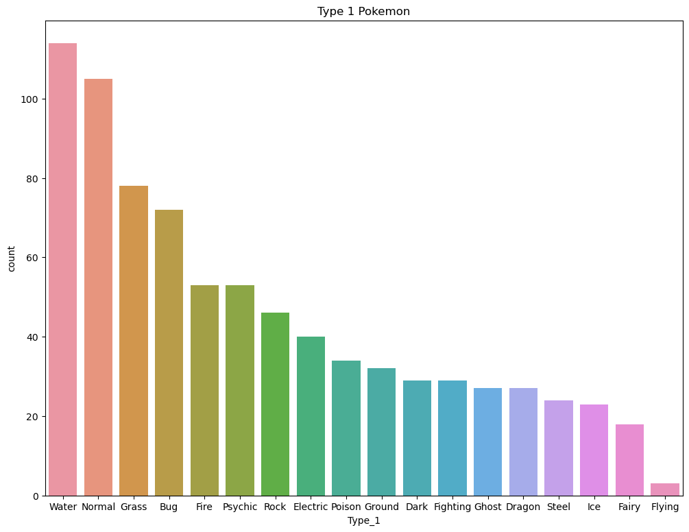

```python
# A bar chart to compare the poketypes
plt.figure(figsize=(12,9))
ax = sb.countplot(x='Type_1', data= pk, order = pk['Type_1'].value_counts().index)
plt.title('Type 1 Pokemon')
```

> This bar chart highlights the different Type 1 poketypes there are in this dataset,and how many pokemon fall into each type.

> The water type seems to be the largest Type 1 level. The flying poketypes isn't very much.

### If that is what type 1 looks like lets check out the 2nd poketype:

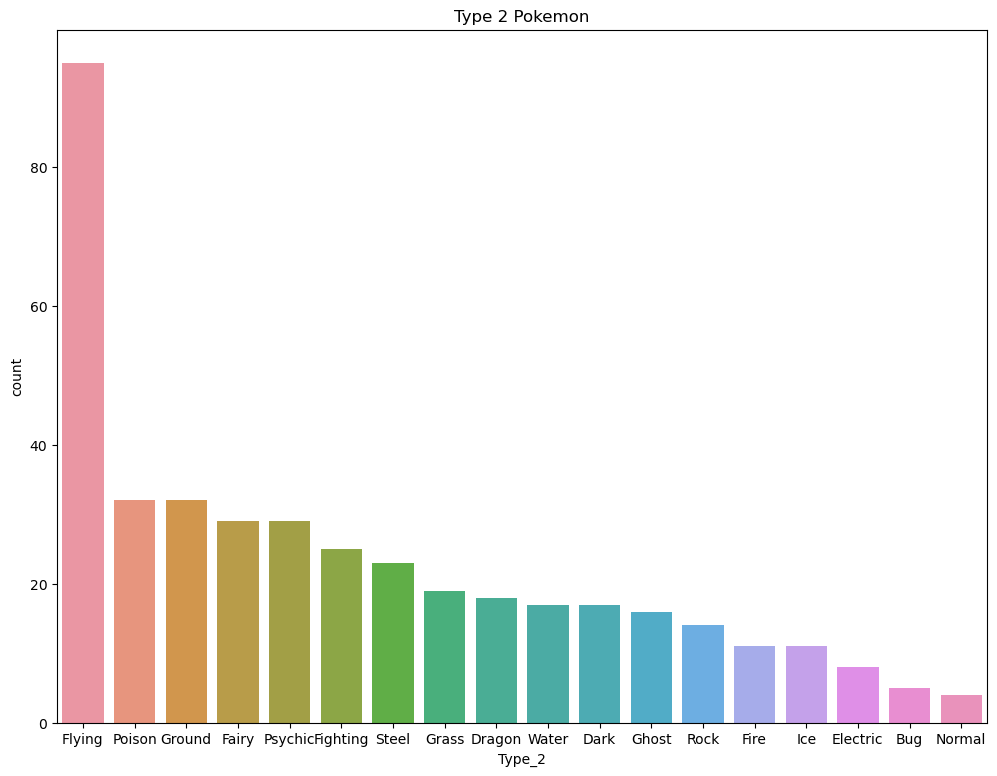

```python
#Display the poketype_2 counts
plt.figure(figsize=(12,9))
ax = sb.countplot(x='Type_2', data= pk, order = pk['Type_2'].value_counts().index)
plt.title('Type 2 Pokemon')
```

**Type 2 PokeTypes**:

Lets create a dataframe to combine the Poketypes for the pokemon that possess more than one type.

```python
# Creating new column for df as "PokeType Combo"
pk['PokeType_Combo'] = (pk['Type_1'] + "+" + pk['Type_2'])
pk['PokeType_Combo'].nunique()
```

```
141
```

```python
pk
```

|  | ID | Species | Generation_ID | Height | Weight | Base_EXP | Type_1 | Type_2 | HP | ATK | DEF | Speed | Special_ATK | Special_DEF | PokeType_Combo |
| --- | --- | --- | --- | --- | --- | --- | --- | --- | --- | --- | --- | --- | --- | --- | --- |
| 0 | 1 | Bulbasaur | 1 | 0.7 | 6.9 | 64 | Grass | Poison | 45 | 49 | 49 | 45 | 65 | 65 | Grass+Poison |
| 1 | 2 | Ivysaur | 1 | 1.0 | 13.0 | 142 | Grass | Poison | 60 | 62 | 63 | 60 | 80 | 80 | Grass+Poison |
| 2 | 3 | Venusaur | 1 | 2.0 | 100.0 | 236 | Grass | Poison | 80 | 82 | 83 | 80 | 100 | 100 | Grass+Poison |
| 3 | 4 | Charmander | 1 | 0.6 | 8.5 | 62 | Fire | NaN | 39 | 52 | 43 | 65 | 60 | 50 | NaN |
| 4 | 5 | Charmeleon | 1 | 1.1 | 19.0 | 142 | Fire | NaN | 58 | 64 | 58 | 80 | 80 | 65 | NaN |
| ... | ... | ... | ... | ... | ... | ... | ... | ... | ... | ... | ... | ... | ... | ... | ... |
| 802 | 803 | Poipole | 7 | 0.6 | 1.8 | 189 | Poison | NaN | 67 | 73 | 67 | 73 | 73 | 67 | NaN |
| 803 | 804 | Naganadel | 7 | 3.6 | 150.0 | 243 | Poison | Dragon | 73 | 73 | 73 | 121 | 127 | 73 | Poison+Dragon |
| 804 | 805 | Stakataka | 7 | 5.5 | 820.0 | 257 | Rock | Steel | 61 | 131 | 211 | 13 | 53 | 101 | Rock+Steel |
| 805 | 806 | Blacephalon | 7 | 1.8 | 13.0 | 257 | Fire | Ghost | 53 | 127 | 53 | 107 | 151 | 79 | Fire+Ghost |
| 806 | 807 | Zeraora | 7 | 1.5 | 44.5 | 270 | Electric | NaN | 88 | 112 | 75 | 143 | 102 | 80 | NaN |

807 rows × 15 columns

```python
#setting a dataframe for single type pokemon by using the NaN value in the Type_2 column.
pk['SingleType'] = pk.Type_2.isnull()
pk['SingleType'] = pk.SingleType.fillna(pk.Type_2)
```

```python
SingleType_Poke = pk[pk.SingleType == True]
DualType_Poke = pk[pk.SingleType == False]
```

```python
print(DualType_Poke)
```

```
      ID       Species  Generation_ID  Height  Weight  Base_EXP    Type_1  \
0      1     Bulbasaur              1     0.7     6.9        64     Grass
1      2       Ivysaur              1     1.0    13.0       142     Grass
2      3      Venusaur              1     2.0   100.0       236     Grass
5      6     Charizard              1     1.7    90.5       240      Fire
11    12    Butterfree              1     1.1    32.0       178       Bug
12    13        Weedle              1     0.3     3.2        39       Bug
13    14        Kakuna              1     0.6    10.0        72       Bug
14    15      Beedrill              1     1.0    29.5       178       Bug
15    16        Pidgey              1     0.3     1.8        50    Normal
16    17     Pidgeotto              1     1.1    30.0       122    Normal
17    18       Pidgeot              1     1.5    39.5       216    Normal
20    21       Spearow              1     0.3     2.0        52    Normal
21    22        Fearow              1     1.2    38.0       155    Normal
30    31     Nidoqueen              1     1.3    60.0       227    Poison
```

[output cut: 1205 more lines]

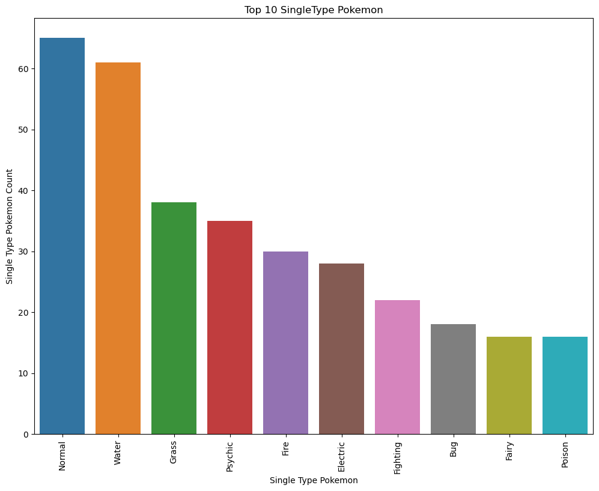

```python
# Show the Top 10 Single poketypes
fig, ax = plt.subplots(figsize=(12, 9))
Single_10 = SingleType_Poke['Type_1'].value_counts()[0:10]
ax = sb.barplot(x = Single_10.index, y=Single_10)
plt.xticks(rotation=90);
plt.xlabel('Single Type Pokemon')
plt.ylabel('Single Type Pokemon Count')
plt.title('Top 10 SingleType Pokemon')
```

This bar chart shows the 10 most single poketypes.

> The normal poketypes are the most common while out of the 10 fairy and poison type come in at a lower portion.

```python
#Create a list for dual type pokemon combos.
DualType = pk[pk['PokeType_Combo'].notna()]
print(DualType)
```

```
      ID       Species  Generation_ID  Height  Weight  Base_EXP    Type_1  \
0      1     Bulbasaur              1     0.7     6.9        64     Grass
1      2       Ivysaur              1     1.0    13.0       142     Grass
2      3      Venusaur              1     2.0   100.0       236     Grass
5      6     Charizard              1     1.7    90.5       240      Fire
11    12    Butterfree              1     1.1    32.0       178       Bug
12    13        Weedle              1     0.3     3.2        39       Bug
13    14        Kakuna              1     0.6    10.0        72       Bug
14    15      Beedrill              1     1.0    29.5       178       Bug
15    16        Pidgey              1     0.3     1.8        50    Normal
16    17     Pidgeotto              1     1.1    30.0       122    Normal
17    18       Pidgeot              1     1.5    39.5       216    Normal
20    21       Spearow              1     0.3     2.0        52    Normal
21    22        Fearow              1     1.2    38.0       155    Normal
30    31     Nidoqueen              1     1.3    60.0       227    Poison
```

[output cut: 1205 more lines]

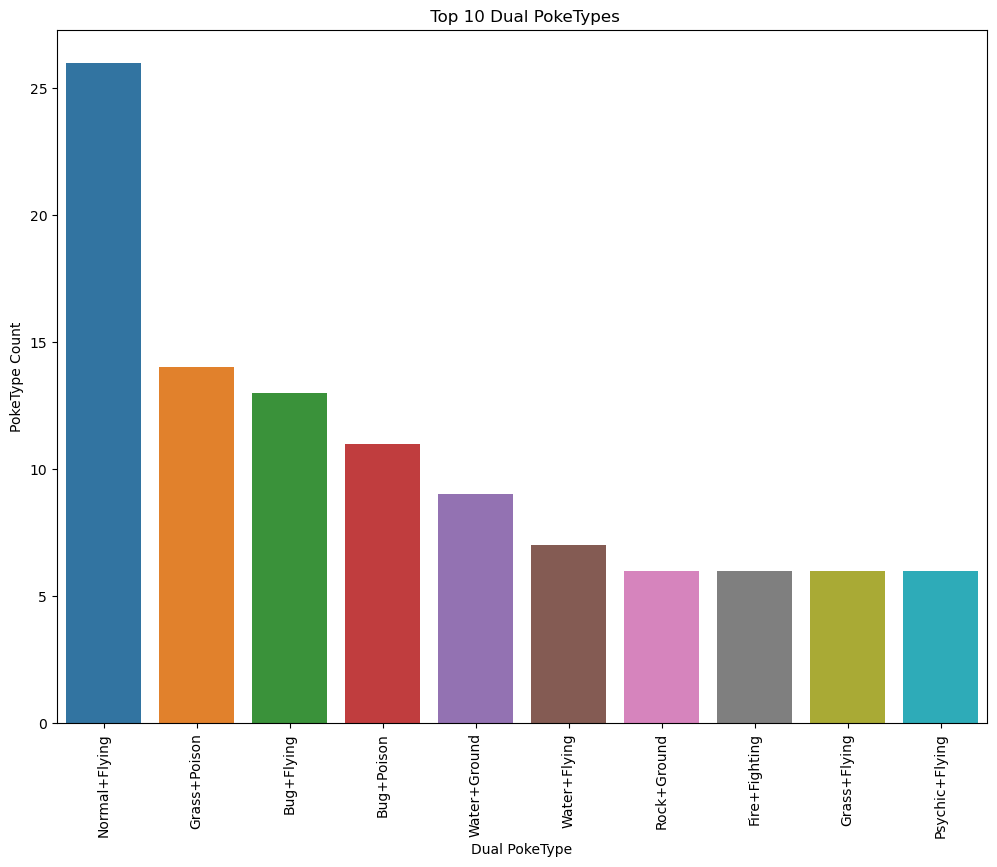

```python
# Show the Top 10 Dual poketype combinations
fig, ax = plt.subplots(figsize=(12, 9))
Combo_10 = DualType['PokeType_Combo'].value_counts()[0:10]
ax = sb.barplot(x = Combo_10.index, y=Combo_10)
plt.xlabel('Dual PokeType')
plt.ylabel('PokeType Count')
plt.title(' Top 10 Dual PokeTypes')
plt.xticks(rotation=90);
```

Out of the Top 10 Dual Type pokemon it seems to be more Normal/Flying poketypes compared to other Dual Types.

### Now that we have the poketype build up, lets see if there is any significance in PokeStats.

```python
pk.Weight.describe()
```

```
count    807.000000
mean      61.771128
std      111.519355
min        0.100000
25%        9.000000
50%       27.000000
75%       63.000000
max      999.900000
Name: Weight, dtype: float64
```

```python
#Creating a dataframe for heavy pokemon
heavy_weight = pk['Weight'].loc[lambda x : x>200]
print(heavy_weight)
```

```
75     300.0
94     210.0
129    235.0
130    220.0
142    460.0
148    210.0
207    400.0
225    220.0
247    202.0
248    216.0
296    253.8
305    360.0
320    398.0
322    220.0
361    256.5
```

[output cut: 45 more lines]

```python
#Create a dataframe for lighter pokemon
light_weight = pk['Weight'].loc[lambda x : x<200]
print(light_weight)
```

```
0        6.9
1       13.0
2      100.0
3        8.5
4       19.0
       ...
801     22.2
802      1.8
803    150.0
805     13.0
806     44.5
Name: Weight, Length: 746, dtype: float64
```

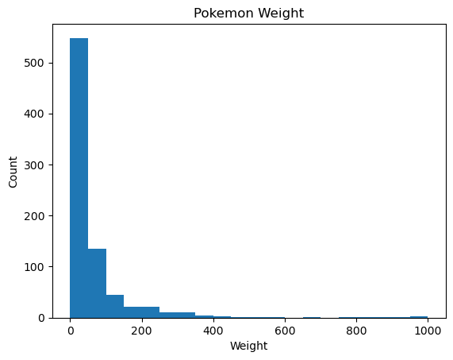

```python
#Using a histogram to visualize the different pokemon weights
plt.hist(data = pk, x = 'Weight', bins = 20)
plt.xlabel('Weight')
plt.ylabel('Count')
plt.title('Pokemon Weight')
```

### What's that distrubution?!

**ITS UNIMODAL!!**

### Poke Attack

> Ultimately we want to gauge a pokemons attack power and seeing a visualization of the various attack point counts helps gather a clearer image of what kind of damage can occur.

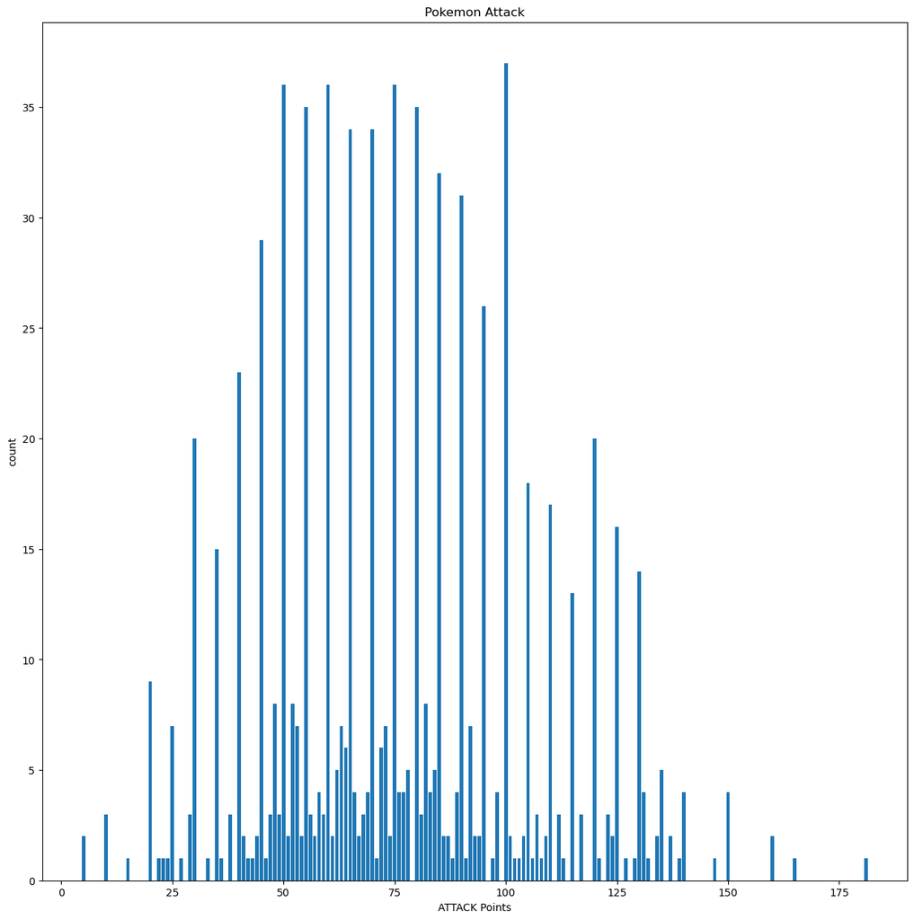

```python
plt.figure(figsize = [15,15])
# Return the Attack column having unique values
x = pk['ATK'].unique()

# Return the column having the frequency count of the unique values
y = pk['ATK'].value_counts(sort=False)

plt.bar(x, y)

# Label the axes
plt.xlabel('ATTACK Points')
plt.ylabel('count')

#Create the title
plt.title('Pokemon Attack')

# Display the plot
plt.show()
```

Using another bar chart we cacn view the attack points for the different pokemon.

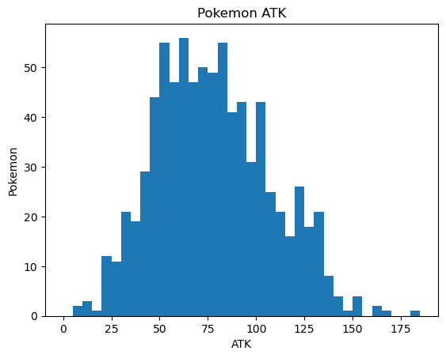

```python
#Histogram for attack points
bins = np.arange(0, pk['ATK'].max()+5, 5)
plt.hist(data = pk, x = 'ATK', bins = bins)
plt.xlabel('ATK')
plt.ylabel('Pokemon')
plt.title('Pokemon ATK')
```

### What's that distrubution?!

```python
# Df for pokestats to use for later charting
PokeStats = ['HP', 'ATK', 'DEF', 'Speed', 'Special_ATK', 'Special_DEF']
```

```python
Stats = PokeStats
```

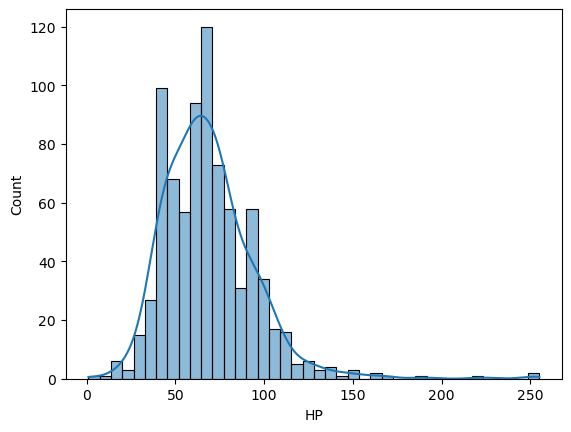

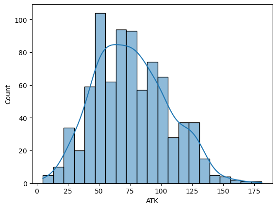

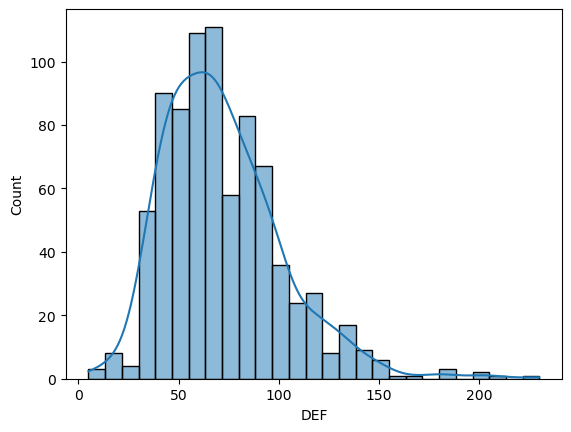

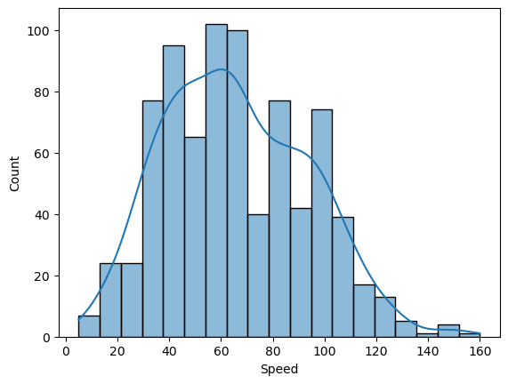

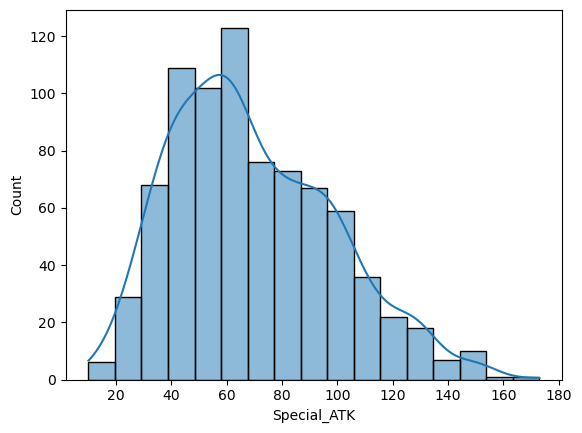

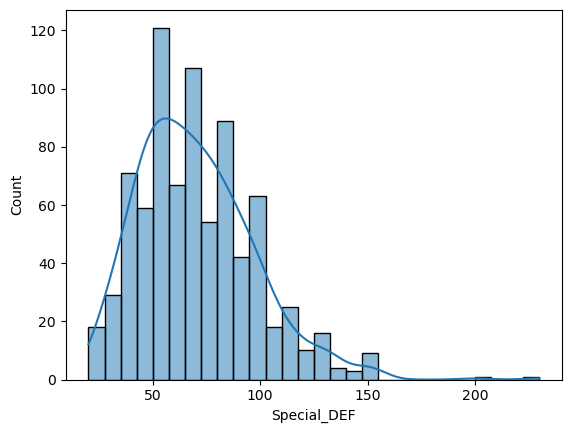

```python
def histo_plot(variable):
    """A histoplot to display Special_ATK and Special_DEF"""
    var = variable
    fig, axs = plt.subplots()
    sb.histplot(data=pk[var], kde = True)
    plt.show()

# Loop for stats List
for i in Stats:
    histo_plot(i)
```

kernel density estimate to smooth the histogram, providing complementary information about the shape of the distribution

# Univariant Recap

### Discuss the distribution(s) of your variable(s) of interest. Were there any unusual points? Did you need to perform any transformations?

> I created a dataframe for single type and dual type pokemon and depicted both poketype counts to see how many different poketypes are in the dataset.

> I ran seaborn's histoplot to display the differnt pokemon stats. KDE is was used to show more information about the distribution shape.

### Of the features you investigated, were there any unusual distributions? Did you perform any operations on the data to tidy, adjust, or change the form of the data? If so, why did you do this?

> I altered the attack bar chart by calling plt.figure(). I felt the information in regard to attack numbers were bunched together so I made the chart wider so that you can make distinctions with the data shown. The attack chart also had the x axis widened past the max value to see it clearly.

## Bivariate Exploration

> In this section, investigate relationships between pairs of variables in your data. Make sure the variables that you cover here have been introduced in some fashion in the previous section (univariate exploration).

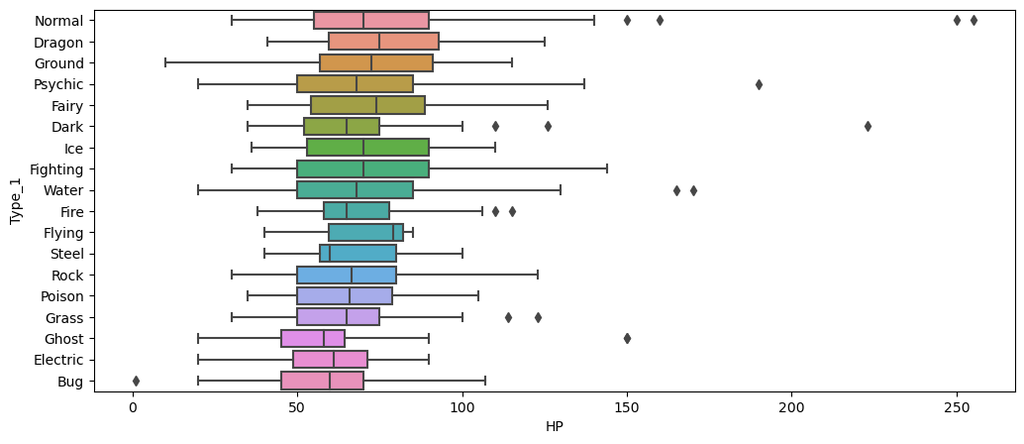

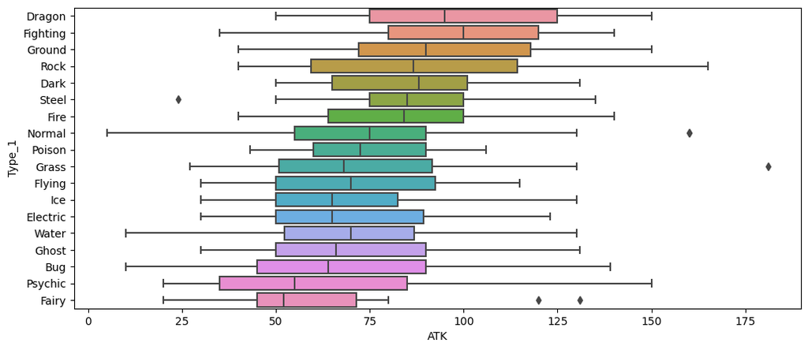

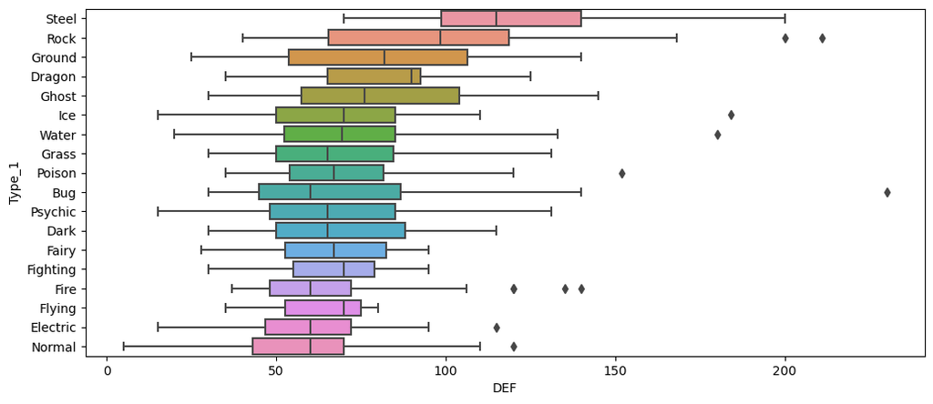

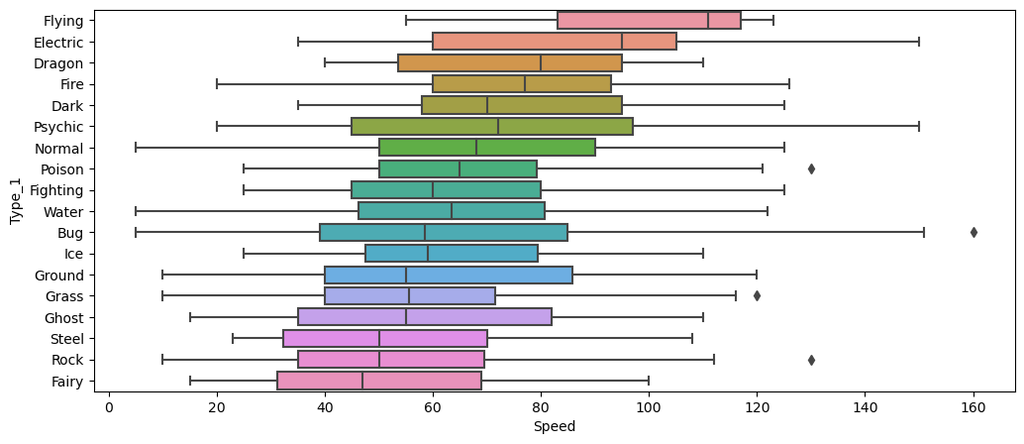

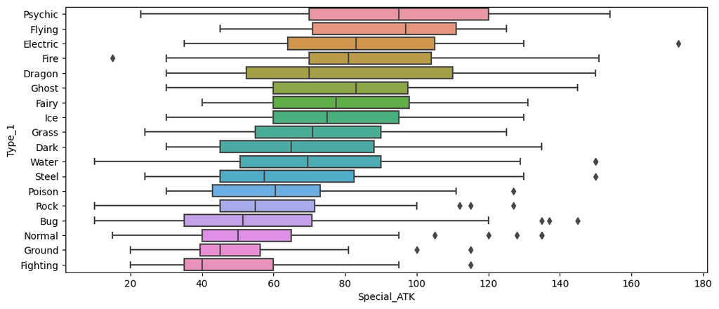

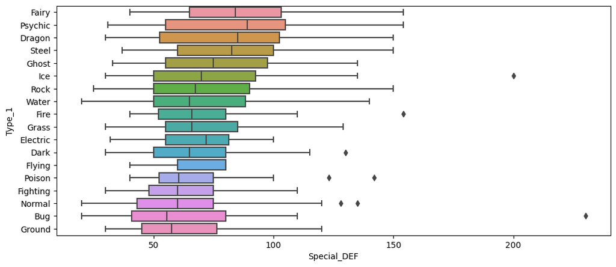

```python
def Statbar_plot(value):
    """Display pokestat differenses for Type_1 poketypes"""
    index_group = pk.groupby(['Type_1']).mean()
    index_order = index_group[value].sort_values(ascending=False)
    fig, axs = plt.subplots(figsize=(12, 5))
    sb.boxplot(data = pk, x = value, y = "Type_1", order = index_order.index)
    plt.show();
# Loop for PokeStats
for i in Stats:
    Statbar_plot(i)
```

> This was done to depict the more favorable or least favorable poketype by their averages.

[figure not shown]

[figure not shown]

[figure not shown]

[figure not shown]

[figure not shown]

[figure not shown]

```python
def singletype_stats(variable):
    """Shows Top 10 for each PokeStat"""
    SingleType_10 = pk.sort_values(by=[variable], ascending=False).head(10)
    fig, axs = plt.subplots(figsize=(10,5))
    sb.barplot(data = SingleType_10, x = variable, y = "Species")
    plt.title("Top 10 "+variable+" for Single Type Pokemon")
    plt.show()

for i in Stats:
    singletype_stats(i)
```

The chart above displays the Pokemon who have the most counts in the different Stat variables.

> I used a top 10 limit to condense my Pokemon and **Shuckle** is the only pokemon to be best in more than one stat variable(Special_DEF and DEF)

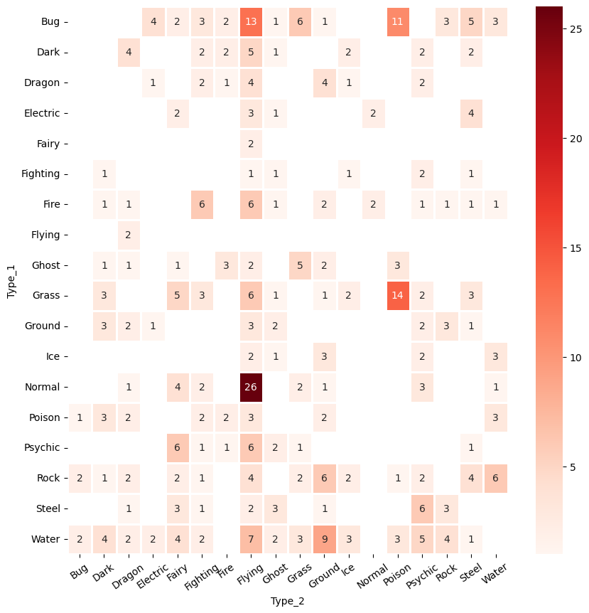

```python
#Create a heatmap to display the num of Poke Dualtypes
plt.subplots(figsize=(10, 10))

sb.heatmap(
    pk[pk['Type_2']!='None'].groupby(['Type_1', 'Type_2']).size().unstack(),
    linewidths=1,
    annot=True,
    cmap="Reds"
)

plt.xticks(rotation=35)
plt.show()
```

The heat map above is used to depict the true numbers of dual type pokemon. You can clearly see the trend in poketypes that are in more than one pokemon.

```python
Top_hp = pk.loc[(pk["Species"] =="Blissey")]
Top_atk = pk.loc[(pk["Species"] =="Kartana")]
Top_def = pk.loc[(pk["Species"] =="Shuckle")]
Top_speed = pk.loc[(pk["Species"] == "Ninjask")]
Top_Special_atk = pk.loc[(pk["Species"] =="Xurkitree")]
Top_Special_def = pk.loc[(pk["Species"] == "Shuckle")]
```

```python
Top_hp
```

|  | ID | Species | Generation_ID | Height | Weight | Base_EXP | Type_1 | Type_2 | HP | ATK | DEF | Speed | Special_ATK | Special_DEF | PokeType_Combo | SingleType |
| --- | --- | --- | --- | --- | --- | --- | --- | --- | --- | --- | --- | --- | --- | --- | --- | --- |
| 241 | 242 | Blissey | 2 | 1.5 | 46.8 | 608 | Normal | NaN | 255 | 10 | 10 | 55 | 75 | 135 | NaN | True |

```python
Top_atk
```

|  | ID | Species | Generation_ID | Height | Weight | Base_EXP | Type_1 | Type_2 | HP | ATK | DEF | Speed | Special_ATK | Special_DEF | PokeType_Combo | SingleType |
| --- | --- | --- | --- | --- | --- | --- | --- | --- | --- | --- | --- | --- | --- | --- | --- | --- |
| 797 | 798 | Kartana | 7 | 0.3 | 0.1 | 257 | Grass | Steel | 59 | 181 | 131 | 109 | 59 | 31 | Grass+Steel | False |

```python
Top_def
```

|  | ID | Species | Generation_ID | Height | Weight | Base_EXP | Type_1 | Type_2 | HP | ATK | DEF | Speed | Special_ATK | Special_DEF | PokeType_Combo | SingleType |
| --- | --- | --- | --- | --- | --- | --- | --- | --- | --- | --- | --- | --- | --- | --- | --- | --- |
| 212 | 213 | Shuckle | 2 | 0.6 | 20.5 | 177 | Bug | Rock | 20 | 10 | 230 | 5 | 10 | 230 | Bug+Rock | False |

```python
Top_speed
```

|  | ID | Species | Generation_ID | Height | Weight | Base_EXP | Type_1 | Type_2 | HP | ATK | DEF | Speed | Special_ATK | Special_DEF | PokeType_Combo | SingleType |
| --- | --- | --- | --- | --- | --- | --- | --- | --- | --- | --- | --- | --- | --- | --- | --- | --- |
| 290 | 291 | Ninjask | 3 | 0.8 | 12.0 | 160 | Bug | Flying | 61 | 90 | 45 | 160 | 50 | 50 | Bug+Flying | False |

```python
Top_Special_atk
```

|  | ID | Species | Generation_ID | Height | Weight | Base_EXP | Type_1 | Type_2 | HP | ATK | DEF | Speed | Special_ATK | Special_DEF | PokeType_Combo | SingleType |
| --- | --- | --- | --- | --- | --- | --- | --- | --- | --- | --- | --- | --- | --- | --- | --- | --- |
| 795 | 796 | Xurkitree | 7 | 3.8 | 100.0 | 257 | Electric | NaN | 83 | 89 | 71 | 83 | 173 | 71 | NaN | True |

```python
Top_Special_def
```

|  | ID | Species | Generation_ID | Height | Weight | Base_EXP | Type_1 | Type_2 | HP | ATK | DEF | Speed | Special_ATK | Special_DEF | PokeType_Combo | SingleType |
| --- | --- | --- | --- | --- | --- | --- | --- | --- | --- | --- | --- | --- | --- | --- | --- | --- |
| 212 | 213 | Shuckle | 2 | 0.6 | 20.5 | 177 | Bug | Rock | 20 | 10 | 230 | 5 | 10 | 230 | Bug+Rock | False |

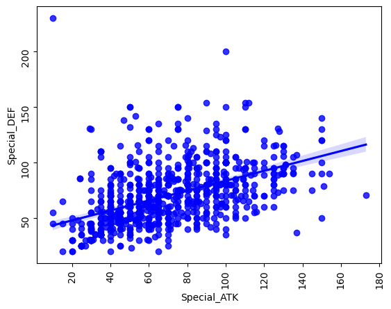

```python
def reggrid(x, y, **kwargs):
    """ reg plot to display both the special ATK and DEF. """
ax = sb.regplot(data = pk, x='Special_ATK', y='Special_DEF', color='b')
ax.tick_params(rotation=90)
```

## Bivariate Recap

### Talk about some of the relationships you observed in this part of the investigation. How did the feature(s) of interest vary with other features in the dataset?

> Displaying the various views of Poketype counts, by boxplot I was able to gather a more direct visualizations of any outliers in the pokestats. I was able to see all of the Type 1 poketypes in 1 chart with the correlating fighting stat. Something that stood out to me was the bug type pokemon has an outlier that is more than the rest of the poketypes in multiple variables like, **DEF, Speed and Special_DEF**

> The second chart is a bar chart and it displays the top 10 individual pokemon species and which one has the most points in each fighting variable.

> The third chart is a heatmap that depicts the different poketype combos. You can see the poketype combinations that occur the most by the highlighted value compared to the other Poketype combos that only occur once.

### Did you observe any interesting relationships between the other features (not the main feature(s) of interest)?

> I noticed that the same Top pokemon species that are in the top 10 do indeed correlate with the outliers in the boxplot depicting the most in the initial chart for most values in the fighting stats by Poketype!

## Multivariate Exploration

> Create plots of three or more variables to investigate your data even further. Make sure that your investigations are justified, and follow from your work in the previous sections.

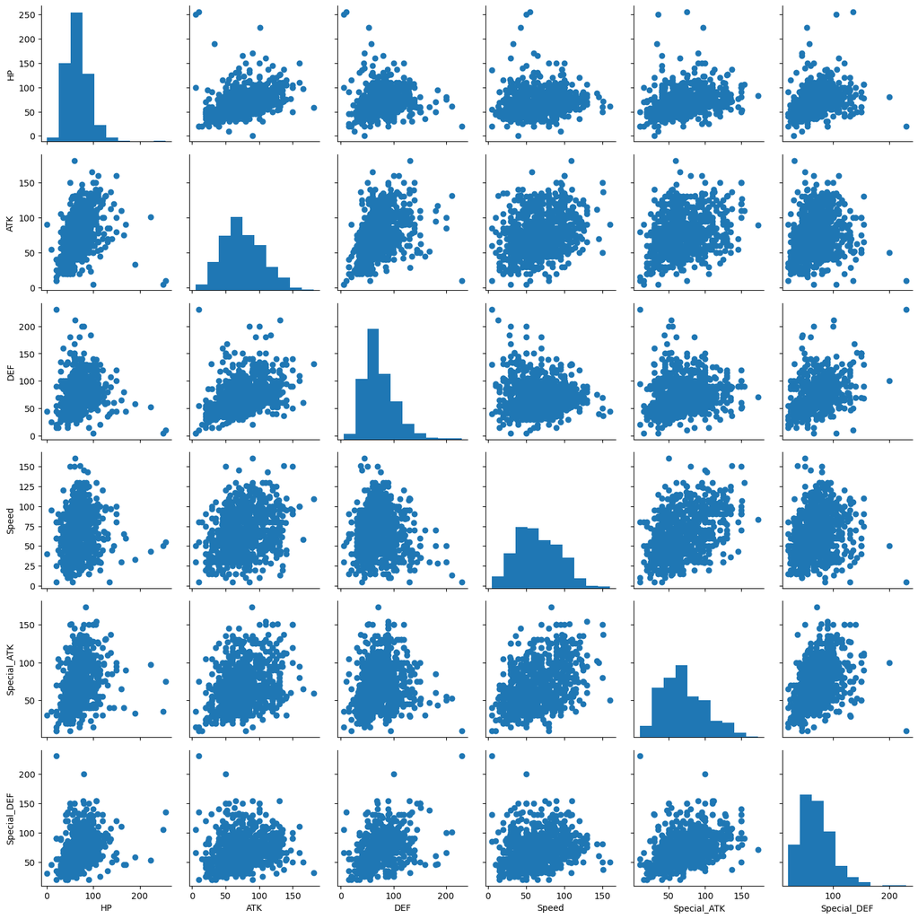

```python
#Depict the relationship between the 6 fighting stats
PokeStats = ['HP', 'ATK', 'DEF', 'Speed', 'Special_ATK', 'Special_DEF']
g = sb.PairGrid(data = pk, vars = PokeStats);
g.map_offdiag(plt.scatter);
g.map_diag(plt.hist);
```

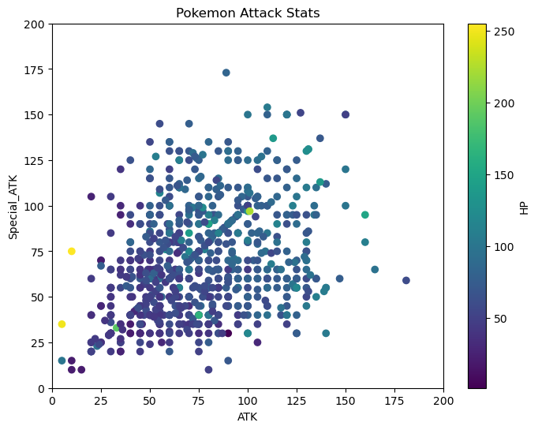

```python
#Show a scatterplot that depicts how HP, Special ATk and Special Defense correlate.
plt.figure(figsize = [8,6])
plt.scatter(data = pk, x = 'ATK', y = 'Special_ATK',
            c = 'HP')
plt.colorbar(label = 'HP')
plt.xlim(0,200)
plt.ylim(0,200)
plt.xlabel('ATK')
plt.ylabel('Special_ATK')
plt.title('Pokemon Attack Stats')
```

The highest amounts on pokemon with high HP are clustered between ATK points of less than 20-100. This chart also shows that the pokemon's Special attack points are also clustered between 25-100.

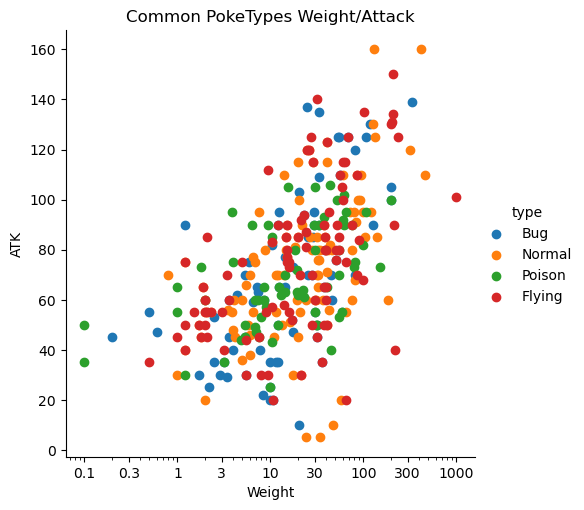

```python
pokemon_sub = pkmn_types.loc[pkmn_types['type'].isin(['Normal','Poison', 'Flying','Bug'])]
# plotting
g = sb.FacetGrid(data = pokemon_sub, hue = 'type', height = 5)
g.map(plt.scatter, 'Weight','ATK')
g.set(xscale = 'log') # need to set scaling before customizing ticks
x_ticks = [0.1, 0.3, 1, 3, 10, 30, 100, 300, 1000]
g.set(xticks = x_ticks, xticklabels = x_ticks)
g.add_legend()
plt.title('Common PokeTypes Weight/Attack')
```

I chose to display the 4 poketypes I saw commonly used to make dualtype pokemon and used their data on attack and weight to see if there is a correlation between the poketype and their attack strength.

> This chart shows that of the poketypes the heaviest pokemon doesn't have the strongest attack points.

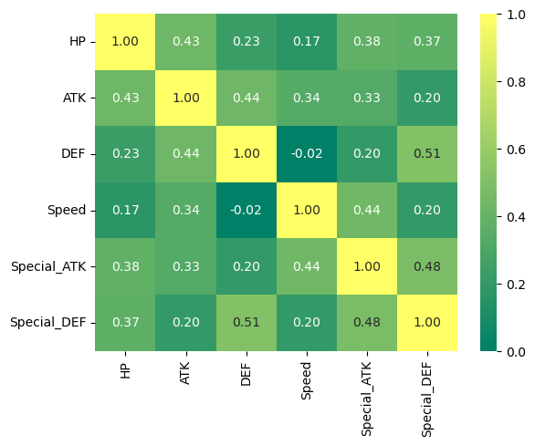

```python
# Heatmap to show groupings of similarites for each pokestat.
sb.heatmap(pk[PokeStats].corr(), cmap = 'summer', annot = True,
          fmt = '.2f', vmin = 0);
```

The heatmap here depicts the correlation between the various pokestats.

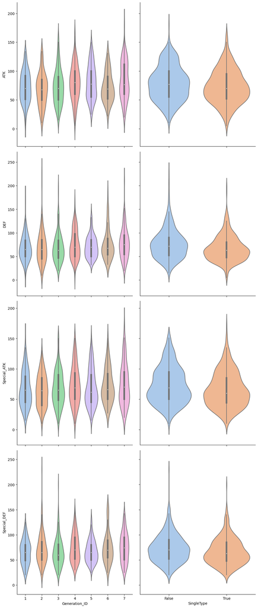

```python
#create a violinplot to depict a combination of boxplot and kernel density estimate.
g = sb.PairGrid(pk,
                 x_vars=["Generation_ID","SingleType"],
                 y_vars=["ATK","DEF","Special_ATK", "Special_DEF"],
                 aspect=.85, height=6)
g.map(sb.violinplot,palette="pastel")
plt.show()
```

I chose to pair the Pokemon Generation and their stats to the Single type/Dual type pokemon. This shows a better picture of which poketype wether single or dual has better stats.

## Multivariate Recap

### Talk about some of the relationships you observed in this part of the investigation. Were there features that strengthened each other in terms of looking at your feature(s) of interest?

> Using the Pokemon battling stats as a comon variable more or less I was able to view in diffent manners how each stat was impacted by either a poketype or the weight of the pokemon!

## Conclusions

```python
pk.to_csv('Pokemon_master.csv', index = False)
```